# CLass Activity - 15-02-2024 - Srujana Vanka

```r
p <- c(0.0050, 0.0010, 0.0100, 0.0005, 0.0009, 0.0400, 0.0560, 0.0500, 0.0480, 0.0130, 0.0370, 0.0430, 0.0020, 0.0250, 0.1100, 0.0700, 0.0800)

bon <- c()
bh <- c()

# Sort the p-values and the corrected p-values
bon <- sort(p.adjust(p, method = "bonferroni"))
bh <- sort(p.adjust(p, method = "BH"))

# Plot the results with custom y-axis tick marks
plot(sort(p), type = "l", col = "black", ylab = "p-values", xlab = "Sorted outcomes", main = "Comparison of p−value Correction Methods", ylim = c(0, 1), yaxt = "n")
axis(2, at = seq(0, 1, by = 0.2), labels = seq(0, 1, by = 0.2))
```

```r
lines(bon, type = "b", col = "green", lty = "dashed")
lines(bh, type = "b", col = "red", lty = "dashed")
```

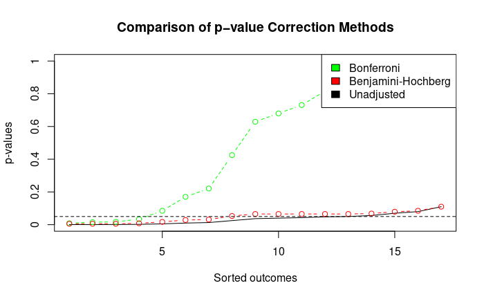

```r
abline(h = 0.05, lty = "dashed")
legend("topright", legend = c("Bonferroni", "Benjamini-Hochberg", "Unadjusted"), fill = c("green", "red", "black"))
```

```r
NA
NA
```

The plot shows the observed (unadjusted) p-values, as well as the corrected p- values.

The Bhenjamini-Hochberg corrected ones lie very close to the line alpha = 0.05 whereas that of Bonferroni are much higher.

As expected, the unadjusted p-values vary widely and include several values that are less than 0.05, the typical threshold for statistical significance. When the p-values are corrected for multiple comparisons, the threshold for statistical significance is much more conservative, and only a few of the p-values remain significant after correction.

The Bonferroni correction is one such method, which is very conservative in that it adjusts the significance level for each test by dividing it by the number of tests being performed.

The Benjamini-Hochberg (BH) correction, on the other hand, is a less conservative method that controls the false discovery rate (FDR) instead of the familywise error rate (FWER). The FDR is the expected proportion of false positives among all the significant results.

When plotting the p-values after correction using these two methods, it’s common to see that the BH-corrected p-values are generally lower than the Bonferroni-corrected p-values. This is because the BH method is less conservative than the Bonferroni method, meaning it allows more significant results to be detected.

Yes, the Bonferroni method is a more conservative approach.